# RNAseq Analysis of Human Reads from Saliva Samples

Shawn Higdon

10/6/2019

```r
library(tidyverse)
library(tximport)
library(DESeq2)
library(tximportData)
library(ensembldb)
library(EnsDb.Hsapiens.v86)
```

# Parallelization

```r
library(BiocParallel)
register(MulticoreParam(3))
```

### Read in Ensembl DB Homo Sapiens

```r
## make edb shortcut
edb <- EnsDb.Hsapiens.v86

## edb info
edb
```

```
## EnsDb for Ensembl:
## |Backend: SQLite
## |Db type: EnsDb
## |Type of Gene ID: Ensembl Gene ID
## |Supporting package: ensembldb
## |Db created by: ensembldb package from Bioconductor
## |script_version: 0.3.0
## |Creation time: Thu May 18 16:32:27 2017
## |ensembl_version: 86
## |ensembl_host: localhost
## |Organism: homo_sapiens
## |taxonomy_id: 9606
## |genome_build: GRCh38
## |DBSCHEMAVERSION: 2.0
## | No. of genes: 63970.
## | No. of transcripts: 216741.
## |Protein data available.
```

```r
## what organism for 'edb'?
organism(edb)
```

```
## [1] "Homo sapiens"
```

# Metadata

## Descriptive Names

```r
# Descriptive names for each sample-subject pair
subject.code <- read_csv("./metadata/BCW_Descriptive_Sample_Names.csv", col_names = T)
```

## Sample Map

```r
# Metadata table for each sample with ST prefix
sample_map <- read_csv("./metadata/MARS-Keen_metadata.csv", col_types = "fffffffff")
colnames(sample_map)
```

```
## [1] "Seq_Label"     "Sample_ID"     "Sex"           "Product"
## [5] "Protein"       "Fortification" "O_N"           "Sample_Type"
## [9] "Timepoint"
```

```r
# Create Descriptive Name
sample_map <- sample_map %>% unite("Code", Sample_ID, Product, Sample_Type, Timepoint, sep = "_", remove = FALSE)

# subset for saliva
saliva_sample_map <- sample_map %>% dplyr::filter(Sample_Type == "Saliva")

head(saliva_sample_map)
```

```
## # A tibble: 6 x 10
##   Seq_Label Code  Sample_ID Sex   Product Protein Fortification O_N
##   <fct>     <chr> <fct>     <fct> <fct>   <fct>   <fct>         <fct>
## 1 ST079     T1C0… T1C018    M     A       12      Non-Fort      O
## 2 ST080     T1C0… T1C018    M     A       12      Non-Fort      O
## 3 ST081     T1C0… T1C047    M     A       12      Non-Fort      N
## 4 ST082     T1C0… T1C047    M     A       12      Non-Fort      N
## 5 ST083     T1C0… T1C048    M     A       12      Non-Fort      N
## 6 ST084     T1C0… T1C048    M     A       12      Non-Fort      N
## # … with 2 more variables: Sample_Type <fct>, Timepoint <fct>
```

# TXIMPORT

> Use `tximport` package to bring in the count data from `salmon`

## Benefits of using `tximport`

- Approach corrects for potential changes in gene length across samples (isoform usage)
- Avoids discarding fragments that can align to multiple genes with homologous sequence (increase sensitivity)

## Locate directory with output from `salmon quant`

> Expt

```r
saliva_dir <- "."
list.files(saliva_dir)
```

```
## [1] "data"                      "DESeq2_LFC_Output"
## [3] "metadata"                  "Saliva_Human_Rnaseq.Rmd"
## [5] "Saliva_human_rnaseq.Rproj" "tx_counts"
```

# Quant File Vector

```r
saliva_files <- file.path(saliva_dir, "data/saliva", saliva_sample_map$Seq_Label, "quant.sf") # Define files of Saliva
names(saliva_files) <- saliva_sample_map$Code # assign names from map file to defined list of saliva input files
names(saliva_files) # print names
```

```
##  [1] "T1C018_A_Saliva_Initial" "T1C018_A_Saliva_Final"
##  [3] "T1C047_A_Saliva_Initial" "T1C047_A_Saliva_Final"
##  [5] "T1C048_A_Saliva_Initial" "T1C048_A_Saliva_Final"
##  [7] "T1C050_A_Saliva_Initial" "T1C050_A_Saliva_Final"
##  [9] "T1C054_A_Saliva_Initial" "T1C054_A_Saliva_Final"
## [11] "T1C056_A_Saliva_Initial" "T1C056_A_Saliva_Final"
## [13] "T1C057_A_Saliva_Initial" "T1C057_A_Saliva_Final"
## [15] "T1C059_A_Saliva_Initial" "T1C059_A_Saliva_Final"
## [17] "T1C063_A_Saliva_Initial" "T1C063_A_Saliva_Final"
## [19] "T1C020_B_Saliva_Initial" "T1C020_B_Saliva_Final"
## [21] "T1C021_B_Saliva_Initial" "T1C021_B_Saliva_Final"
## [23] "T1C029_B_Saliva_Initial" "T1C029_B_Saliva_Final"
## [25] "T1C031_B_Saliva_Initial" "T1C031_B_Saliva_Final"
## [27] "T1C037_B_Saliva_Initial" "T1C037_B_Saliva_Final"
## [29] "T1C044_B_Saliva_Initial" "T1C044_B_Saliva_Final"
```

[output cut: 25 more lines]

```r
all(file.exists(saliva_files))
```

```
## [1] TRUE
```

```r
print(saliva_files)
```

```
##        T1C018_A_Saliva_Initial          T1C018_A_Saliva_Final
## "./data/saliva/ST079/quant.sf" "./data/saliva/ST080/quant.sf"
##        T1C047_A_Saliva_Initial          T1C047_A_Saliva_Final
## "./data/saliva/ST081/quant.sf" "./data/saliva/ST082/quant.sf"
##        T1C048_A_Saliva_Initial          T1C048_A_Saliva_Final
## "./data/saliva/ST083/quant.sf" "./data/saliva/ST084/quant.sf"
##        T1C050_A_Saliva_Initial          T1C050_A_Saliva_Final
## "./data/saliva/ST085/quant.sf" "./data/saliva/ST086/quant.sf"
##        T1C054_A_Saliva_Initial          T1C054_A_Saliva_Final
## "./data/saliva/ST087/quant.sf" "./data/saliva/ST088/quant.sf"
##        T1C056_A_Saliva_Initial          T1C056_A_Saliva_Final
## "./data/saliva/ST089/quant.sf" "./data/saliva/ST090/quant.sf"
##        T1C057_A_Saliva_Initial          T1C057_A_Saliva_Final
## "./data/saliva/ST091/quant.sf" "./data/saliva/ST092/quant.sf"
##        T1C059_A_Saliva_Initial          T1C059_A_Saliva_Final
## "./data/saliva/ST093/quant.sf" "./data/saliva/ST094/quant.sf"
##        T1C063_A_Saliva_Initial          T1C063_A_Saliva_Final
## "./data/saliva/ST095/quant.sf" "./data/saliva/ST096/quant.sf"
##        T1C020_B_Saliva_Initial          T1C020_B_Saliva_Final
## "./data/saliva/ST097/quant.sf" "./data/saliva/ST098/quant.sf"
##        T1C021_B_Saliva_Initial          T1C021_B_Saliva_Final
## "./data/saliva/ST099/quant.sf" "./data/saliva/ST100/quant.sf"
##        T1C029_B_Saliva_Initial          T1C029_B_Saliva_Final
## "./data/saliva/ST101/quant.sf" "./data/saliva/ST102/quant.sf"
##        T1C031_B_Saliva_Initial          T1C031_B_Saliva_Final
## "./data/saliva/ST103/quant.sf" "./data/saliva/ST104/quant.sf"
##        T1C037_B_Saliva_Initial          T1C037_B_Saliva_Final
## "./data/saliva/ST105/quant.sf" "./data/saliva/ST106/quant.sf"
##        T1C044_B_Saliva_Initial          T1C044_B_Saliva_Final
## "./data/saliva/ST107/quant.sf" "./data/saliva/ST108/quant.sf"
##        T1C060_B_Saliva_Initial          T1C060_B_Saliva_Final
## "./data/saliva/ST109/quant.sf" "./data/saliva/ST110/quant.sf"
##        T1C062_B_Saliva_Initial          T1C062_B_Saliva_Final
## "./data/saliva/ST111/quant.sf" "./data/saliva/ST112/quant.sf"
##        T1C073_B_Saliva_Initial          T1C073_B_Saliva_Final
## "./data/saliva/ST113/quant.sf" "./data/saliva/ST114/quant.sf"
##        T1C077_B_Saliva_Initial          T1C077_B_Saliva_Final
## "./data/saliva/ST115/quant.sf" "./data/saliva/ST116/quant.sf"
##        T1C022_C_Saliva_Initial          T1C022_C_Saliva_Final
## "./data/saliva/ST117/quant.sf" "./data/saliva/ST118/quant.sf"
```

[output cut: 25 more lines]

```
## "./data/saliva/ST143/quant.sf" "./data/saliva/ST144/quant.sf"
##        T1C051_D_Saliva_Initial          T1C051_D_Saliva_Final
## "./data/saliva/ST145/quant.sf" "./data/saliva/ST146/quant.sf"
##        T1C053_D_Saliva_Initial          T1C053_D_Saliva_Final
## "./data/saliva/ST147/quant.sf" "./data/saliva/ST148/quant.sf"
##        T1C058_D_Saliva_Initial          T1C058_D_Saliva_Final
## "./data/saliva/ST149/quant.sf" "./data/saliva/ST150/quant.sf"
##        T1C061_D_Saliva_Initial          T1C061_D_Saliva_Final
## "./data/saliva/ST151/quant.sf" "./data/saliva/ST152/quant.sf"
##        T1C069_D_Saliva_Initial          T1C069_D_Saliva_Final
## "./data/saliva/ST153/quant.sf" "./data/saliva/ST154/quant.sf"
##        T1C071_D_Saliva_Initial          T1C071_D_Saliva_Final
## "./data/saliva/ST155/quant.sf" "./data/saliva/ST156/quant.sf"
##        T1C072_D_Saliva_Initial          T1C072_D_Saliva_Final
## "./data/saliva/ST157/quant.sf" "./data/saliva/ST158/quant.sf"
```

# Associate TX ID with Gene ID for gene-level summarization

> Make a dataframe called `ensembl_tx2gene` with 2 columns: 1) Transcript ID and 2) gene ID. Transcript ID is in abundance files (quant files)

```r
listColumns(edb, "tx")
```

```
## [1] "tx_id"            "tx_biotype"       "tx_seq_start"
## [4] "tx_seq_end"       "tx_cds_seq_start" "tx_cds_seq_end"
## [7] "gene_id"          "tx_name"
```

```r
ensembl_tx2gene <- transcripts(edb,
                               columns = c("tx_id", "gene_id"),
                               return.type = "DataFrame")

head(ensembl_tx2gene, n=10)
```

```
## DataFrame with 10 rows and 2 columns
##              tx_id         gene_id
##        <character>     <character>
## 1  ENST00000000233 ENSG00000004059
## 2  ENST00000000412 ENSG00000003056
## 3  ENST00000000442 ENSG00000173153
## 4  ENST00000001008 ENSG00000004478
## 5  ENST00000001146 ENSG00000003137
## 6  ENST00000002125 ENSG00000003509
## 7  ENST00000002165 ENSG00000001036
## 8  ENST00000002501 ENSG00000003249
## 9  ENST00000002596 ENSG00000002587
## 10 ENST00000002829 ENSG00000001617
```

## Use `tximport` (import transcript-level estimates from **Salmon** quant.sf files)

> Import counts and keep tx_id labels for transcript import

```r
saliva_ensembl_txi.tx <- tximport(saliva_files, type = "salmon", txOut = TRUE)
```

```
## reading in files with read_tsv
```

```
## 1 2 3 4 5 6 7 8 9 10 11 12 13 14 15 16 17 18 19 20 21 22 23 24 25 26 27 28 29 30 31 32 33 34 35 36 37 38 39 40 41 42 43 44 45 46 47 48 49 50 51 52 53 54 55 56 57 58 59 60 61 62 63 64 65 66 67 68 69 70 71 72 73 74 75 76 77 78 79 80
```

```r
head(saliva_ensembl_txi.tx$counts)
```

```
##                   T1C018_A_Saliva_Initial T1C018_A_Saliva_Final
## ENST00000632684.1                       0                     0
## ENST00000434970.2                       0                     0
## ENST00000448914.1                       0                     0
## ENST00000415118.1                       0                     0
## ENST00000390583.1                       0                     0
## ENST00000390577.1                       0                     0
##                   T1C047_A_Saliva_Initial T1C047_A_Saliva_Final
## ENST00000632684.1                       0                     0
## ENST00000434970.2                       0                     0
## ENST00000448914.1                       0                     0
## ENST00000415118.1                       0                     0
## ENST00000390583.1                       0                     0
## ENST00000390577.1                       0                     0
##                   T1C048_A_Saliva_Initial T1C048_A_Saliva_Final
## ENST00000632684.1                       0                     0
## ENST00000434970.2                       0                     0
## ENST00000448914.1                       0                     0
## ENST00000415118.1                       0                     0
## ENST00000390583.1                       0                     0
## ENST00000390577.1                       0                     0
##                   T1C050_A_Saliva_Initial T1C050_A_Saliva_Final
## ENST00000632684.1                       0                     0
## ENST00000434970.2                       0                     0
## ENST00000448914.1                       0                     0
## ENST00000415118.1                       0                     0
## ENST00000390583.1                       0                     0
## ENST00000390577.1                       0                     0
##                   T1C054_A_Saliva_Initial T1C054_A_Saliva_Final
## ENST00000632684.1                       0                     0
## ENST00000434970.2                       0                     0
## ENST00000448914.1                       0                     0
## ENST00000415118.1                       0                     0
## ENST00000390583.1                       0                     0
## ENST00000390577.1                       0                     0
##                   T1C056_A_Saliva_Initial T1C056_A_Saliva_Final
## ENST00000632684.1                       0                     0
## ENST00000434970.2                       0                     0
## ENST00000448914.1                       0                     0
## ENST00000415118.1                       0                     0
```

[output cut: 225 more lines]

```
## ENST00000390577.1                       0                     0
##                   T1C071_D_Saliva_Initial T1C071_D_Saliva_Final
## ENST00000632684.1                       0                     0
## ENST00000434970.2                       0                     0
## ENST00000448914.1                       0                     0
## ENST00000415118.1                       0                     0
## ENST00000390583.1                       0                     0
## ENST00000390577.1                       0                     0
##                   T1C072_D_Saliva_Initial T1C072_D_Saliva_Final
## ENST00000632684.1                       0                     0
## ENST00000434970.2                       0                     0
## ENST00000448914.1                       0                     0
## ENST00000415118.1                       0                     0
## ENST00000390583.1                       0                     0
## ENST00000390577.1                       0                     0
```

> Summarize counts to gene level

```r
saliva_ensembl_txi.sum <- summarizeToGene(saliva_ensembl_txi.tx, ensembl_tx2gene, ignoreTxVersion = TRUE)
```

```
## transcripts missing from tx2gene: 6521
```

```
## summarizing abundance
```

```
## summarizing counts
```

```
## summarizing length
```

```r
all.equal(saliva_ensembl_txi.tx$counts, saliva_ensembl_txi.sum$counts)
```

```
## [1] "Attributes: < Component \"dim\": Mean relative difference: 0.6593775 >"
## [2] "Attributes: < Component \"dimnames\": Component 1: 42602 string mismatches >"
## [3] "Numeric: lengths (10005680, 3408160) differ"
```

## DESeq2

### Design: ~ Timepoint (Contrast by sample timepoint)

```r
# Make rownames of sample map the same as column names in transcript table
colnames(saliva_ensembl_txi.sum$counts)
```

```
##  [1] "T1C018_A_Saliva_Initial" "T1C018_A_Saliva_Final"
##  [3] "T1C047_A_Saliva_Initial" "T1C047_A_Saliva_Final"
##  [5] "T1C048_A_Saliva_Initial" "T1C048_A_Saliva_Final"
##  [7] "T1C050_A_Saliva_Initial" "T1C050_A_Saliva_Final"
##  [9] "T1C054_A_Saliva_Initial" "T1C054_A_Saliva_Final"
## [11] "T1C056_A_Saliva_Initial" "T1C056_A_Saliva_Final"
## [13] "T1C057_A_Saliva_Initial" "T1C057_A_Saliva_Final"
## [15] "T1C059_A_Saliva_Initial" "T1C059_A_Saliva_Final"
## [17] "T1C063_A_Saliva_Initial" "T1C063_A_Saliva_Final"
## [19] "T1C020_B_Saliva_Initial" "T1C020_B_Saliva_Final"
## [21] "T1C021_B_Saliva_Initial" "T1C021_B_Saliva_Final"
## [23] "T1C029_B_Saliva_Initial" "T1C029_B_Saliva_Final"
## [25] "T1C031_B_Saliva_Initial" "T1C031_B_Saliva_Final"
## [27] "T1C037_B_Saliva_Initial" "T1C037_B_Saliva_Final"
## [29] "T1C044_B_Saliva_Initial" "T1C044_B_Saliva_Final"
```

[output cut: 25 more lines]

```r
rownames(saliva_sample_map) <- saliva_sample_map$Code
rownames(saliva_sample_map)
```

```
##  [1] "T1C018_A_Saliva_Initial" "T1C018_A_Saliva_Final"
##  [3] "T1C047_A_Saliva_Initial" "T1C047_A_Saliva_Final"
##  [5] "T1C048_A_Saliva_Initial" "T1C048_A_Saliva_Final"
##  [7] "T1C050_A_Saliva_Initial" "T1C050_A_Saliva_Final"
##  [9] "T1C054_A_Saliva_Initial" "T1C054_A_Saliva_Final"
## [11] "T1C056_A_Saliva_Initial" "T1C056_A_Saliva_Final"
## [13] "T1C057_A_Saliva_Initial" "T1C057_A_Saliva_Final"
## [15] "T1C059_A_Saliva_Initial" "T1C059_A_Saliva_Final"
## [17] "T1C063_A_Saliva_Initial" "T1C063_A_Saliva_Final"
## [19] "T1C020_B_Saliva_Initial" "T1C020_B_Saliva_Final"
## [21] "T1C021_B_Saliva_Initial" "T1C021_B_Saliva_Final"
## [23] "T1C029_B_Saliva_Initial" "T1C029_B_Saliva_Final"
## [25] "T1C031_B_Saliva_Initial" "T1C031_B_Saliva_Final"
## [27] "T1C037_B_Saliva_Initial" "T1C037_B_Saliva_Final"
## [29] "T1C044_B_Saliva_Initial" "T1C044_B_Saliva_Final"
```

[output cut: 25 more lines]

```r
ddsTxi_time <- DESeqDataSetFromTximport(saliva_ensembl_txi.sum,
                                   colData = saliva_sample_map,
                                   design = ~ Timepoint)
```

```
## using counts and average transcript lengths from tximport
```

#### Pre-filtering

> Remove transcripts that have less than ten counts in total for the entire row (all samples)

```r
ddsTxi_time.filter <- rowSums(counts(ddsTxi_time)) >= 10
ddsTxi_time <- ddsTxi_time[ddsTxi_time.filter,]
```

#### Factor Level for Condition

> Set the reference level to `initial` condition

```r
ddsTxi_time$Condition <- relevel(ddsTxi_time$Timepoint, ref = "Initial")
```

#### Differential Expression Analysis

> Standard differential expression analysis steps are consolidated into a single fuction: `DESeq`
- Results tables are generated using the function `results()`, which extracts a results table with log2 fold changes, *p* values and **adjusted *p* values**.
- The `results()` function produces **log2-fold change** and **Wald test *p* value** for the last variable in the **design formula**
- If this is a factor, the comparison will be the **last level** of this variable over the **reference level**:

```r
ddsTxi_time <- DESeq(ddsTxi_time, parallel = TRUE)
```

```
## using 'avgTxLength' from assays(dds), correcting for library size
```

```
## -- replacing outliers and refitting for 2205 genes
## -- DESeq argument 'minReplicatesForReplace' = 7
## -- original counts are preserved in counts(dds)
```

```r
ddsTxi_time.res <- results(ddsTxi_time, parallel = TRUE)
ddsTxi_time.res
```

```
## log2 fold change (MLE): Timepoint Final vs Initial
## Wald test p-value: Timepoint Final vs Initial
## DataFrame with 28525 rows and 6 columns
##                           baseMean      log2FoldChange             lfcSE
##                          <numeric>           <numeric>         <numeric>
## ENSG00000000003  0.398788909293441  -0.906746716997172  1.11036492293156
## ENSG00000000419  0.448097390904489   -0.19091486341774 0.810112355706122
## ENSG00000000457   0.63375786765953 -0.0216988960776991 0.629808201953611
## ENSG00000000460   1.24574527871654  -0.246394562313582 0.441200460836975
## ENSG00000000938   2.82563127458983   -0.53868673721321 0.577929145518718
## ...                            ...                 ...               ...
## ENSG00000283689 0.0472353636379522  -0.340071132986718  1.86990614677418
## ENSG00000283692  0.236193839917899  -0.172256705930942 0.811228089375852
## ENSG00000283696   10.8845486090239  -0.507825313193403 0.200924125609322
## ENSG00000283697 0.0949681039303054   -1.03210321349482  1.95215423330256
## ENSG00000283699  0.722574684773975 -0.0578214448164008 0.541119060825387
##                                stat             pvalue              padj
##                           <numeric>          <numeric>         <numeric>
## ENSG00000000003  -0.816620462580173  0.414145357535395                NA
## ENSG00000000419  -0.235664673020981  0.813692884679516                NA
## ENSG00000000457 -0.0344531811595831  0.972515776184739                NA
## ENSG00000000460  -0.558463973147631  0.576527599000888                NA
## ENSG00000000938  -0.932098236246095   0.35128575946831 0.945402741662212
## ...                             ...                ...               ...
## ENSG00000283689  -0.181865348468629  0.855688398866015                NA
## ENSG00000283692  -0.212340657562134  0.831841278407468                NA
## ENSG00000283696   -2.52744816807526 0.0114894781954672 0.612975532237365
## ENSG00000283697  -0.528699626232275  0.597013836517653                NA
## ENSG00000283699  -0.106855309676587  0.914903767835389                NA
```

#### Log fold change shrinkage for visualization and ranking

> Shrinkage of effect size (LFC estimates) is useful for visualization and ranking of genes.

> To shrink LFC, the `ddsTxi` object is passed through the function `lfcshrink()`.
- Uses the `apeglm` method for effect size shrinkage: improves on previous estimator.

```r
resultsNames(ddsTxi_time)
```

```
## [1] "Intercept"                  "Timepoint_Final_vs_Initial"
```

```r
ddsTxi_time.res.LFC <- lfcShrink(ddsTxi_time, coef = "Timepoint_Final_vs_Initial", type = "apeglm", parallel = TRUE)
```

```
## using 'apeglm' for LFC shrinkage. If used in published research, please cite:
##     Zhu, A., Ibrahim, J.G., Love, M.I. (2018) Heavy-tailed prior distributions for
##     sequence count data: removing the noise and preserving large differences.
##     Bioinformatics. https://doi.org/10.1093/bioinformatics/bty895
```

```r
ddsTxi_time.res.LFC
```

```
## log2 fold change (MAP): Timepoint Final vs Initial
## Wald test p-value: Timepoint Final vs Initial
## DataFrame with 28525 rows and 5 columns
##                           baseMean        log2FoldChange
##                          <numeric>             <numeric>
## ENSG00000000003  0.398788909293441 -9.80645744798083e-07
## ENSG00000000419  0.448097390904489 -5.14916298122734e-08
## ENSG00000000457   0.63375786765953  1.99744859702549e-06
## ENSG00000000460   1.24574527871654 -1.55702779093817e-06
## ENSG00000000938   2.82563127458983  -1.6792201691551e-07
## ...                            ...                   ...
## ENSG00000283689 0.0472353636379522 -2.17007009508844e-07
## ENSG00000283692  0.236193839917899 -1.81214283416573e-07
## ENSG00000283696   10.8845486090239 -1.61029487143328e-05
## ENSG00000283697 0.0949681039303054 -5.65714132286384e-07
## ENSG00000283699  0.722574684773975  6.32803284124937e-08
##                               lfcSE             pvalue              padj
##                           <numeric>          <numeric>         <numeric>
## ENSG00000000003 0.00144269424197092  0.414145357535395                NA
## ENSG00000000419  0.0014426930702694  0.813692884679516                NA
## ENSG00000000457 0.00144269203821577  0.972515776184739                NA
## ENSG00000000460 0.00144268773534471  0.576527599000888                NA
## ENSG00000000938 0.00144269038236568   0.35128575946831 0.945402741662212
## ...                             ...                ...               ...
## ENSG00000283689 0.00144269476443285  0.855688398866015                NA
## ENSG00000283692 0.00144269351153071  0.831841278407468                NA
## ENSG00000283696 0.00144270399585331 0.0114894781954672 0.612975532237365
## ENSG00000283697  0.0014426949210817  0.597013836517653                NA
## ENSG00000283699 0.00144269052619909  0.914903767835389                NA
```

> One can use parallelization if the dataset is large (dozens of coefficients, ~100s of samples)

> Load `BiocParallel` package; set arguments `parallel=TRUE` and `BPPARAM=MulticoreParam(3)` for `DESeq`, `results` and `lfcshrink`

#### Order results table by *adjusted p-value*

```r
ddsTxi_time.res.LFC.ordered <- ddsTxi_time.res.LFC[order(ddsTxi_time.res.LFC$padj),]
```

### Summarize the results table

```r
summary(ddsTxi_time.res.LFC.ordered)
```

```
##
## out of 28525 with nonzero total read count
## adjusted p-value < 0.1
## LFC > 0 (up)       : 1, 0.0035%
## LFC < 0 (down)     : 18, 0.063%
## outliers [1]       : 0, 0%
## low counts [2]     : 22121, 78%
## (mean count < 1)
## [1] see 'cooksCutoff' argument of ?results
## [2] see 'independentFiltering' argument of ?results
```

> 18 genes with decreased LFC in expression for final timepoint compared with initial timepoint (expression decreased after treatment) at adjusted p-value less than 0.1

### Export Results

```r
# subset
ddsTxi_time.res.LFC.ordered.sig <- subset(ddsTxi_time.res.LFC.ordered, padj < 0.1)

ddsTxi_time.res.LFC.ordered.sig
```

```
## log2 fold change (MAP): Timepoint Final vs Initial
## Wald test p-value: Timepoint Final vs Initial
## DataFrame with 19 rows and 5 columns
##                         baseMean        log2FoldChange               lfcSE
##                        <numeric>             <numeric>           <numeric>
## ENSG00000100731 12.6975937730446  -3.3150205238486e-06 0.00144269377189907
## ENSG00000166579   5.269464575222 -1.49553936607842e-06 0.00144269199772108
## ENSG00000168781 5.36882446755216     -1.45487601376605    0.52254744805221
## ENSG00000174718 28.1705646854257 -2.21959114073013e-06 0.00144269241186639
## ENSG00000198712 69.9477740247839    -0.780107113130325   0.433058711705277
## ...                          ...                   ...                 ...
## ENSG00000198786 359.360304626032 -5.54189951616167e-06 0.00144268239617364
## ENSG00000198840 30.0828763482722     -1.16377395198345   0.367137454927787
## ENSG00000198899 64.5180840091004    -0.562512305720183   0.447978691869953
## ENSG00000198938 105.376809227308    -0.922331087033681   0.307994905183506
## ENSG00000264112 3.00065253710363 -5.54076455573219e-06 0.00144269584194378
##                               pvalue               padj
##                            <numeric>          <numeric>
## ENSG00000100731 7.10710378196511e-06 0.0455138926197046
## ENSG00000166579 7.62226431257498e-05 0.0701093331531867
## ENSG00000168781 8.40113291038572e-05 0.0701093331531867
## ENSG00000174718 2.81614696792292e-05 0.0701093331531867
## ENSG00000198712 7.70891748947425e-05 0.0701093331531867
## ...                              ...                ...
## ENSG00000198786 0.000274438094092315 0.0925000818193255
## ENSG00000198840 0.000263565702852933 0.0925000818193255
## ENSG00000198899 0.000270211036136392 0.0925000818193255
## ENSG00000198938 0.000192675221446769 0.0925000818193255
## ENSG00000264112  0.00025322698273415 0.0925000818193255
```

```r
write.csv(as.data.frame(ddsTxi_time.res.LFC.ordered.sig),
          file = "DESeq2_LFC_Output/MARS_human_saliva_timepoint_final_vs_initial_all_products_deseq2_lfcshrink_sig_results.csv")
```

### MA-plot

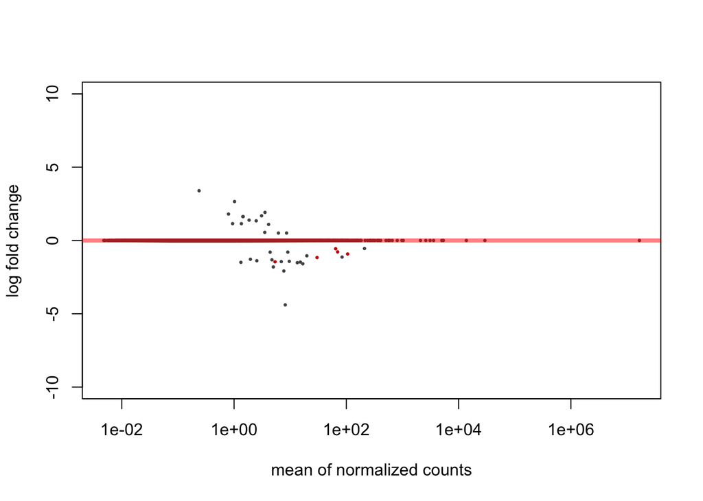

```r
plotMA(ddsTxi_time.res.LFC, ylim=c(-10,10))
```

### Design: ~ Micronutrient Fortification (Contrast by treatments that either contained micronutrient fortification or did not)

```r
colnames(saliva_sample_map)
```

```
##  [1] "Seq_Label"     "Code"          "Sample_ID"     "Sex"
##  [5] "Product"       "Protein"       "Fortification" "O_N"
##  [9] "Sample_Type"   "Timepoint"
```

```r
ddsTxi_fort <- DESeqDataSetFromTximport(saliva_ensembl_txi.sum,
                                   colData = saliva_sample_map,
                                   design = ~ Fortification)
```

```
##   Note: levels of factors in the design contain characters other than
##   letters, numbers, '_' and '.'. It is recommended (but not required) to use
##   only letters, numbers, and delimiters '_' or '.', as these are safe characters
##   for column names in R. [This is a message, not an warning or error]
```

```
## using counts and average transcript lengths from tximport
```

#### Pre-filtering

> Remove transcripts that have less than ten counts in total for the entire row (all samples)

```r
ddsTxi_fort.filter <- rowSums(counts(ddsTxi_fort)) >= 10
ddsTxi_fort <- ddsTxi_fort[ddsTxi_fort.filter,]
```

#### Factor Level for Condition

```r
ddsTxi_fort$Condition <- relevel(ddsTxi_fort$Fortification, ref = "Non-Fort")
```

#### Differential Expression Analysis

> Standard differential expression analysis steps are consolidated into a single fuction: `DESeq`
- Results tables are generated using the function `results()`, which extracts a results table with log2 fold changes, *p* values and **adjusted *p* values**.
- The `results()` function produces **log2-fold change** and **Wald test *p* value** for the last variable in the **design formula**
- If this is a factor, the comparison will be the **last level** of this variable over the **reference level**:

```r
ddsTxi_fort <- DESeq(ddsTxi_fort, parallel = TRUE)
```

```
##   Note: levels of factors in the design contain characters other than
##   letters, numbers, '_' and '.'. It is recommended (but not required) to use
##   only letters, numbers, and delimiters '_' or '.', as these are safe characters
##   for column names in R. [This is a message, not an warning or error]
```

```
## using 'avgTxLength' from assays(dds), correcting for library size
```

[output not shown]

[output not shown]

[output not shown]

```
## -- replacing outliers and refitting for 1263 genes
## -- DESeq argument 'minReplicatesForReplace' = 7
## -- original counts are preserved in counts(dds)
```

[output not shown]

[output not shown]

```r
ddsTxi_fort.res <- results(ddsTxi_fort, parallel = TRUE)
ddsTxi_fort.res
```

```
## log2 fold change (MLE): Fortification Fort vs Non.Fort
## Wald test p-value: Fortification Fort vs Non.Fort
## DataFrame with 28525 rows and 6 columns
##                           baseMean      log2FoldChange             lfcSE
##                          <numeric>           <numeric>         <numeric>
## ENSG00000000003  0.398788909293441    1.80001733698316  1.02821647204678
## ENSG00000000419  0.448097390904489    1.04249434764777 0.790328237757467
## ENSG00000000457   0.63375786765953   0.804081836292738 0.615754295380216
## ENSG00000000460   1.24574527871654  -0.469794045710918 0.450548485164273
## ENSG00000000938   3.23459355399592    1.94828875054635 0.554512846846043
## ...                            ...                 ...               ...
## ENSG00000283689 0.0472353636379522    1.08914410260396  1.86422921959565
## ENSG00000283692  0.236193839917899   0.522013029112987 0.832245493683755
## ENSG00000283696   10.8845486090239  -0.242072557319125 0.206333461929465
## ENSG00000283697 0.0949681039303054   0.069281327799573  1.92844939649044
## ENSG00000283699  0.722574684773975 0.00964078167511396 0.541535030820922
##                               stat               pvalue               padj
##                          <numeric>            <numeric>          <numeric>
## ENSG00000000003   1.75062098878851   0.0800112174420653                 NA
## ENSG00000000419   1.31906503885754    0.187147369940715                 NA
## ENSG00000000457   1.30584852160265    0.191604075639867                 NA
## ENSG00000000460  -1.04271584786181     0.29707991580447  0.596532674073248
## ENSG00000000938   3.51351418028964 0.000442220808921672 0.0150477935759885
## ...                            ...                  ...                ...
## ENSG00000283689  0.584232931849547    0.559063608059535                 NA
## ENSG00000283692  0.627234431516605    0.530505576421165                 NA
## ENSG00000283696  -1.17321037051119    0.240711454321515  0.540809011893203
## ENSG00000283697 0.0359259246966278    0.971341424288412                 NA
## ENSG00000283699 0.0178026925801999    0.985796256732774  0.995321612552801
```

#### Log fold change shrinkage for visualization and ranking

> Shrinkage of effect size (LFC estimates) is useful for visualization and ranking of genes.

> To shrink LFC, the `ddsTxi` object is passed through the function `lfcshrink()`.
- Uses the `apeglm` method for effect size shrinkage: improves on previous estimator.

```r
resultsNames(ddsTxi_fort)
```

```
## [1] "Intercept"                      "Fortification_Fort_vs_Non.Fort"
```

```r
ddsTxi_fort.res.LFC <- lfcShrink(ddsTxi_fort, coef = "Fortification_Fort_vs_Non.Fort", type = "apeglm", parallel = TRUE)
```

```
## using 'apeglm' for LFC shrinkage. If used in published research, please cite:
##     Zhu, A., Ibrahim, J.G., Love, M.I. (2018) Heavy-tailed prior distributions for
##     sequence count data: removing the noise and preserving large differences.
##     Bioinformatics. https://doi.org/10.1093/bioinformatics/bty895
```

```r
ddsTxi_fort.res.LFC
```

```
## log2 fold change (MAP): Fortification Fort vs Non.Fort
## Wald test p-value: Fortification Fort vs Non.Fort
## DataFrame with 28525 rows and 5 columns
##                           baseMean      log2FoldChange             lfcSE
##                          <numeric>           <numeric>         <numeric>
## ENSG00000000003  0.398788909293441   0.152761620520018 0.341179863222717
## ENSG00000000419  0.448097390904489  0.0991332967220629 0.296039500926046
## ENSG00000000457   0.63375786765953   0.426977277546792 0.667408425034923
## ENSG00000000460   1.24574527871654  -0.180524782007095 0.293162493076335
## ENSG00000000938   3.23459355399592    1.59264905221337 0.620326475569064
## ...                            ...                 ...               ...
## ENSG00000283689 0.0472353636379522  0.0361368604714621 0.289701654580236
## ENSG00000283692  0.236193839917899 -0.0233926721756935 0.278354191340379
## ENSG00000283696   10.8845486090239   -0.16628816928873 0.182390782580187
## ENSG00000283697 0.0949681039303054 -0.0286495054978215 0.288171224389221
## ENSG00000283699  0.722574684773975 -0.0261049762857394 0.259350651870275
##                               pvalue               padj
##                            <numeric>          <numeric>
## ENSG00000000003   0.0800112174420653                 NA
## ENSG00000000419    0.187147369940715                 NA
## ENSG00000000457    0.191604075639867                 NA
## ENSG00000000460     0.29707991580447  0.596532674073248
## ENSG00000000938 0.000442220808921672 0.0150477935759885
## ...                              ...                ...
## ENSG00000283689    0.559063608059535                 NA
## ENSG00000283692    0.530505576421165                 NA
## ENSG00000283696    0.240711454321515  0.540809011893203
## ENSG00000283697    0.971341424288412                 NA
## ENSG00000283699    0.985796256732774  0.995321612552801
```

> One can use parallelization if the dataset is large (dozens of coefficients, ~100s of samples)

> Load `BiocParallel` package; set arguments `parallel=TRUE` and `BPPARAM=MulticoreParam(3)` for `DESeq`, `results` and `lfcshrink`

#### Order results table by *adjusted p-value*

```r
ddsTxi_fort.res.LFC.ordered <- ddsTxi_fort.res.LFC[order(ddsTxi_fort.res.LFC$padj),]
```

### Summarize the results table

```r
summary(ddsTxi_fort.res.LFC.ordered)
```

```
##
## out of 28525 with nonzero total read count
## adjusted p-value < 0.1
## LFC > 0 (up)       : 934, 3.3%
## LFC < 0 (down)     : 146, 0.51%
## outliers [1]       : 0, 0%
## low counts [2]     : 18250, 64%
## (mean count < 1)
## [1] see 'cooksCutoff' argument of ?results
## [2] see 'independentFiltering' argument of ?results
```

### Export Results

```r
# subset
ddsTxi_fort.res.LFC.ordered.sig <- subset(ddsTxi_fort.res.LFC.ordered, padj < 0.1)

ddsTxi_fort.res.LFC.ordered.sig
```

```
## log2 fold change (MAP): Fortification Fort vs Non.Fort
## Wald test p-value: Fortification Fort vs Non.Fort
## DataFrame with 1080 rows and 5 columns
##                         baseMean     log2FoldChange             lfcSE
##                        <numeric>          <numeric>         <numeric>
## ENSG00000239002  57.997263338255   2.75560980118037 0.525207802289934
## ENSG00000081237 85.6158906528174   2.76643105171232 0.702087908962708
## ENSG00000248223 361.909273324036  -2.06767214847262 0.320524836013197
## ENSG00000198840  63.190089741091   1.36077369428608 0.431561463119377
## ENSG00000198888 215.639462179014   1.48546205555276 0.409180869519255
## ...                          ...                ...               ...
## ENSG00000128881 1.33118451400566  0.341925408086009  0.60827187866433
## ENSG00000131013 1.07459605554808  0.312335316120391 0.639385922236035
## ENSG00000213079 1.19794065555771   0.91982723578673  1.65807079832945
## ENSG00000262679  3.0457295169116 -0.658127748897737 0.433912379627173
## ENSG00000073331 4.08141233557007  0.315622020250028 0.523862070887502
##                               pvalue                 padj
##                            <numeric>            <numeric>
## ENSG00000239002  2.0986110919195e-13 2.15632289694728e-09
## ENSG00000081237 8.05131675336496e-13 4.13636398204125e-09
## ENSG00000248223 5.90569580909751e-12  2.0227008146159e-08
## ENSG00000198840 6.33144602483802e-11 1.62639019763027e-07
## ENSG00000198888 2.71263986824213e-10 5.57447492923758e-07
## ...                              ...                  ...
## ENSG00000128881   0.0104338054332706   0.0995546188756196
## ENSG00000131013   0.0104394068771863   0.0995546188756196
## ENSG00000213079   0.0104544461086904   0.0995546188756196
## ENSG00000262679   0.0104528716864327   0.0995546188756196
## ENSG00000073331   0.0104987739515633   0.0998841688447344
```

```r
write.csv(as.data.frame(ddsTxi_fort.res.LFC.ordered.sig),
          file = "DESeq2_LFC_Output/MARS_human_saliva_fort_vs_non-fort_all_times_deseq2_lfcshrink_sig_results.csv")
```

### MA-plot

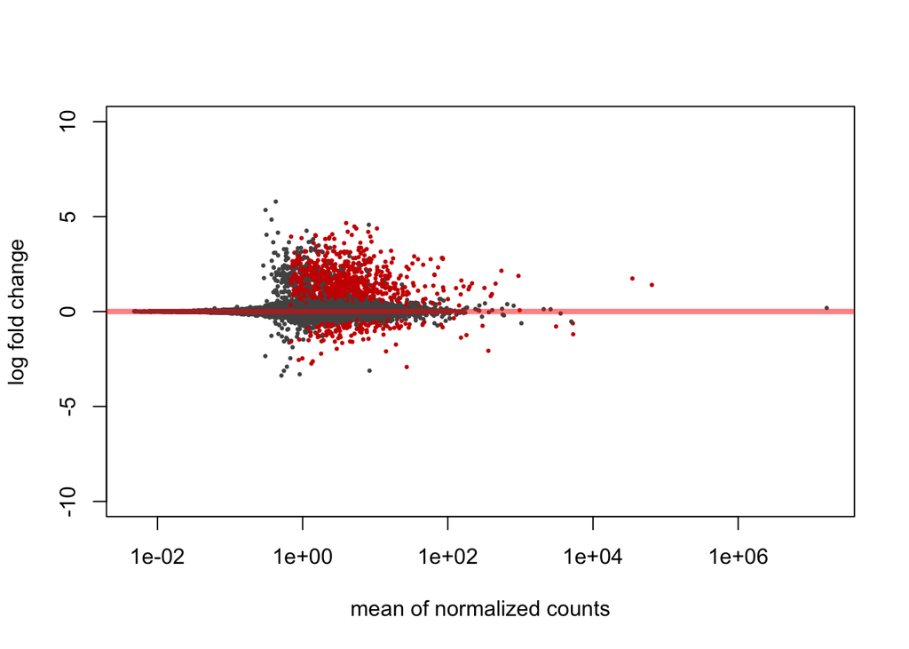

```r
plotMA(ddsTxi_fort.res.LFC, ylim=c(-10,10))
```

### Design: ~ Factorial (Product + Timepoint)

```r
colnames(saliva_sample_map)
```

```
##  [1] "Seq_Label"     "Code"          "Sample_ID"     "Sex"
##  [5] "Product"       "Protein"       "Fortification" "O_N"
##  [9] "Sample_Type"   "Timepoint"
```

```r
ddsTxi_MF <- DESeqDataSetFromTximport(saliva_ensembl_txi.sum,
                                   colData = saliva_sample_map,
                                   design = ~ Product + Timepoint)
```

```
## using counts and average transcript lengths from tximport
```

```r
levels(ddsTxi_MF$Product)
```

```
## [1] "A" "B" "C" "D"
```

```r
levels(ddsTxi_MF$Timepoint)
```

```
## [1] "Initial" "Final"
```

#### Pre-filtering

> Remove transcripts that have less than ten counts in total for the entire row (all samples)

```r
ddsTxi_MF.filter <- rowSums(counts(ddsTxi_MF)) >= 10
ddsTxi_MF <- ddsTxi_MF[ddsTxi_MF.filter,]
```

#### Differential Expression Analysis

> Standard differential expression analysis steps are consolidated into a single fuction: `DESeq`
- Results tables are generated using the function `results()`, which extracts a results table with log2 fold changes, *p* values and **adjusted *p* values**.
- The `results()` function produces **log2-fold change** and **Wald test *p* value** for the last variable in the **design formula**
- If this is a factor, the comparison will be the **last level** of this variable over the **reference level**:

```r
ddsTxi_MF <- DESeq(ddsTxi_MF, parallel = TRUE)
```

```
## using 'avgTxLength' from assays(dds), correcting for library size
```

```
## -- replacing outliers and refitting for 1094 genes
## -- DESeq argument 'minReplicatesForReplace' = 7
## -- original counts are preserved in counts(dds)
```

##### Contrast: Product B vs. D

> Product B: 6 g Protein with Micronutrient Fortification

> Product D: 6 g Protein without Micronutrient Fortification

```r
ddsTxi_MF.res.BvD <- results(ddsTxi_MF,
                         parallel = TRUE,
                         contrast = c("Product", "B", "D")) # B is numerator of log2 ratio, D is denominator of log2 ratio
ddsTxi_MF.res.BvD
```

```
## log2 fold change (MLE): Product B vs D
## Wald test p-value: Product B vs D
## DataFrame with 28525 rows and 6 columns
##                           baseMean     log2FoldChange             lfcSE
##                          <numeric>          <numeric>         <numeric>
## ENSG00000000003  0.398788909293441     2.380760979618  1.61798454435884
## ENSG00000000419  0.448097390904489   1.33863618422838  1.12298827692153
## ENSG00000000457  0.771036293104657    2.1482945503181 0.867202715460536
## ENSG00000000460   1.24574527871654 -0.712138431974187 0.629198260402797
## ENSG00000000938   3.23459355399592   2.27938666080928 0.770214620169199
## ...                            ...                ...               ...
## ENSG00000283689 0.0472353636379522   1.55171775999537   3.1416432877007
## ENSG00000283692  0.236193839917899  0.726592410975852   1.1997592020783
## ENSG00000283696   10.8845486090239 -0.242840258250204 0.281195326670155
## ENSG00000283697 0.0949681039303054   0.31953731773765  3.30802951640401
## ENSG00000283699  0.722574684773975 -0.671158097052844 0.748585776071221
##                               stat              pvalue               padj
##                          <numeric>           <numeric>          <numeric>
## ENSG00000000003   1.47143616910223   0.141173197943148                 NA
## ENSG00000000419   1.19203041718121   0.233249318730152                 NA
## ENSG00000000457   2.47726916903994  0.0132392015390068  0.105501243739528
## ENSG00000000460  -1.13181881894952   0.257710614190273  0.540786227316605
## ENSG00000000938   2.95941754560378 0.00308221171203887 0.0451284070247619
## ...                            ...                 ...                ...
## ENSG00000283689  0.493919142911682   0.621363284610587                 NA
## ENSG00000283692   0.60561520154811   0.544770305471145                 NA
## ENSG00000283696 -0.863599908027837   0.387807714704901  0.663393015064113
## ENSG00000283697 0.0965944578647542   0.923048457897393                 NA
## ENSG00000283699 -0.896568060076244   0.369949447798306                 NA
```

#### Order results table by *adjusted p-value*

```r
ddsTxi_MF.res.BvD.ordered <- ddsTxi_MF.res.BvD[order(ddsTxi_MF.res.BvD$padj),]
```

### Summarize the results table

```r
summary(ddsTxi_MF.res.BvD.ordered)
```

```
##
## out of 28524 with nonzero total read count
## adjusted p-value < 0.1
## LFC > 0 (up)       : 1010, 3.5%
## LFC < 0 (down)     : 158, 0.55%
## outliers [1]       : 0, 0%
## low counts [2]     : 18803, 66%
## (mean count < 1)
## [1] see 'cooksCutoff' argument of ?results
## [2] see 'independentFiltering' argument of ?results
```

### Export Results

```r
# subset to keep p-adj < 0.1
ddsTxi_MF.res.BvD.sig1 <- subset(ddsTxi_MF.res.BvD.ordered, padj < 0.1)

ddsTxi_MF.res.BvD.sig1
```

```
## log2 fold change (MLE): Product B vs D
## Wald test p-value: Product B vs D
## DataFrame with 1168 rows and 6 columns
##                          baseMean    log2FoldChange             lfcSE
##                         <numeric>         <numeric>         <numeric>
## ENSG00000248223  361.909273324036 -2.80329634974846 0.394898240541463
## ENSG00000260807  27.6470680806617  1.68293720947158 0.242687476743237
## ENSG00000081237  92.0007712195084  5.72340844081305 0.920689922647204
## ENSG00000157106   17.621832604464  4.05436202227379 0.694143338248635
## ENSG00000138081  3.14196525706594  4.64771751314656 0.809804044690108
## ...                           ...               ...               ...
## ENSG00000137154   4.4569332464408  2.58196083444559  1.02604280209768
## ENSG00000162613 0.809006206336817  3.61193321263209  1.43521013077042
## ENSG00000198837  1.80767817046507  1.80395484694329 0.716974607593922
## ENSG00000115464  13.8564938744315  1.60143396711871 0.636562870376652
## ENSG00000111144  5.53521467603793 0.863037546819762 0.343479871238636
##                              stat               pvalue
##                         <numeric>            <numeric>
## ENSG00000248223 -7.09878156434613 1.25861552775987e-12
## ENSG00000260807  6.93458612721134 4.07412134368817e-12
## ENSG00000081237  6.21643432824471 5.08579088966618e-10
## ENSG00000157106   5.8408138476171 5.19464237644432e-09
## ENSG00000138081  5.73931131070742 9.50623327608106e-09
## ...                           ...                  ...
## ENSG00000137154  2.51642604886163   0.0118551776233881
## ENSG00000162613  2.51665810824037   0.0118473730497592
## ENSG00000198837  2.51606518255527   0.0118673232629823
## ENSG00000115464  2.51575145463817   0.0118778913356103
## ENSG00000111144  2.51262917884396   0.0119835223231135
##                                 padj
##                            <numeric>
## ENSG00000248223 1.22362601608815e-08
## ENSG00000260807 1.98043038516682e-08
## ENSG00000081237 1.64813530097782e-06
## ENSG00000157106 1.26255782959479e-05
## ENSG00000138081  1.8483919982012e-05
## ...                              ...
## ENSG00000137154   0.0989322204760335
## ENSG00000162613   0.0989322204760335
## ENSG00000198837   0.0989486421635625
## ENSG00000115464   0.0989518933717251
## ENSG00000111144   0.0997464075559158
```

```r
write.csv(as.data.frame(ddsTxi_MF.res.BvD.sig1),
          file = "DESeq2_LFC_Output/MARS_human_saliva_product_plus_timepoint_B.vs.D_deseq2_noshrink_padj_0.1_results_all_samples.csv")


# subset to keep p-adj < 0.05
ddsTxi_MF.res.BvD.sig05 <- subset(ddsTxi_MF.res.BvD.ordered, padj < 0.05)

ddsTxi_MF.res.BvD.sig05
```

```
## log2 fold change (MLE): Product B vs D
## Wald test p-value: Product B vs D
## DataFrame with 721 rows and 6 columns
##                          baseMean    log2FoldChange             lfcSE
##                         <numeric>         <numeric>         <numeric>
## ENSG00000248223  361.909273324036 -2.80329634974846 0.394898240541463
## ENSG00000260807  27.6470680806617  1.68293720947158 0.242687476743237
## ENSG00000081237  92.0007712195084  5.72340844081305 0.920689922647204
## ENSG00000157106   17.621832604464  4.05436202227379 0.694143338248635
## ENSG00000138081  3.14196525706594  4.64771751314656 0.809804044690108
## ...                           ...               ...               ...
## ENSG00000197405   2.5936823429453  2.25696302900925 0.776784659637195
## ENSG00000067064  1.86160460544561  3.28112583550044  1.12999604957947
## ENSG00000276918  1.61912389629168 -1.37264682496009 0.472751077891798
## ENSG00000077549  1.74489194914477   2.3941104993721 0.824681262538469
## ENSG00000225725 0.865480672578924  2.08800364782273 0.719461887827474
##                              stat               pvalue
##                         <numeric>            <numeric>
## ENSG00000248223 -7.09878156434613 1.25861552775987e-12
## ENSG00000260807  6.93458612721134 4.07412134368817e-12
## ENSG00000081237  6.21643432824471 5.08579088966618e-10
## ENSG00000157106   5.8408138476171 5.19464237644432e-09
## ENSG00000138081  5.73931131070742 9.50623327608106e-09
## ...                           ...                  ...
## ENSG00000197405  2.90551956840058  0.00366643922418854
## ENSG00000067064  2.90366133290602  0.00368826888279946
## ENSG00000276918 -2.90352976260005  0.00368981897816492
## ENSG00000077549  2.90307371844819  0.00369519644730021
## ENSG00000225725  2.90217408753615  0.00370582538994172
##                                 padj
##                            <numeric>
## ENSG00000248223 1.22362601608815e-08
## ENSG00000260807 1.98043038516682e-08
## ENSG00000081237 1.64813530097782e-06
## ENSG00000157106 1.26255782959479e-05
## ENSG00000138081  1.8483919982012e-05
## ...                              ...
## ENSG00000197405    0.049714256816682
## ENSG00000067064   0.0498921002861188
## ENSG00000276918   0.0498921002861188
## ENSG00000077549   0.0498954164731287
## ENSG00000225725   0.0499695345922516
```

```r
write.csv(as.data.frame(ddsTxi_MF.res.BvD.sig05),
          file = "DESeq2_LFC_Output/MARS_human_saliva_product_plus_timepoint_B.vs.D_deseq2_noshrink_padj_0.05_results_all_samples.csv")
```

### Design: Interactions-Factorial (Product + Timepoint)

```r
colnames(saliva_sample_map)
```

```
##  [1] "Seq_Label"     "Code"          "Sample_ID"     "Sex"
##  [5] "Product"       "Protein"       "Fortification" "O_N"
##  [9] "Sample_Type"   "Timepoint"
```

```r
ddsTxi_MFI <- ddsTxi_MF # copy

ddsTxi_MFI$group <- factor(paste(ddsTxi_MFI$Product, ddsTxi_MFI$Timepoint, sep = "."))
design(ddsTxi_MFI) <- ~ group
levels(ddsTxi_MFI$group)
```

```
## [1] "A.Final"   "A.Initial" "B.Final"   "B.Initial" "C.Final"   "C.Initial"
## [7] "D.Final"   "D.Initial"
```

```r
ddsTxi_MFI <- DESeq(ddsTxi_MFI,
                    parallel = TRUE)
```

```
## -- replacing outliers and refitting for 1019 genes
## -- DESeq argument 'minReplicatesForReplace' = 7
## -- original counts are preserved in counts(dds)
```

#### Product B * Time

> Product B: 6 g Protein with Micronutrient Fortification

```r
ddsTxi_MFI.B.time <- results(ddsTxi_MFI,
                             parallel = TRUE,
                             contrast = c("group", "B.Final", "B.Initial")) # B.Final is numerator of log2 ratio, B.Initial is denominator of log2 ratio

ddsTxi_MFI.B.time
```

```
## log2 fold change (MLE): group B.Final vs B.Initial
## Wald test p-value: group B.Final vs B.Initial
## DataFrame with 28525 rows and 6 columns
##                           baseMean     log2FoldChange             lfcSE
##                          <numeric>          <numeric>         <numeric>
## ENSG00000000003  0.398788909293441 -0.296754954757961  2.70181093603445
## ENSG00000000419  0.448097390904489 0.0179318329669831  1.92594063482175
## ENSG00000000457  0.771036293104657  0.720611166262988    1.376026806887
## ENSG00000000460   1.24574527871654 -0.190552151541907  1.05910075840201
## ENSG00000000938   3.23459355399592 -0.317288950562922  1.13222931741949
## ...                            ...                ...               ...
## ENSG00000283689 0.0472353636379522 -0.281446224973681  5.83211809674482
## ENSG00000283692  0.236193839917899 -0.849580295716191  2.06430302726872
## ENSG00000283696   10.8845486090239 -0.273502246446088 0.447775715845109
## ENSG00000283697 0.0949681039303054 -0.343783292655418  5.83157552352794
## ENSG00000283699  0.722574684773975  -1.00567209071444  1.17904776373661
##                                stat            pvalue      padj
##                           <numeric>         <numeric> <numeric>
## ENSG00000000003  -0.109835573910852 0.912539777810272         1
## ENSG00000000419 0.00931068831653927 0.992571252873614         1
## ENSG00000000457   0.523689773088966 0.600494329906405         1
## ENSG00000000460  -0.179918813229268 0.857216305390893         1
## ENSG00000000938  -0.280233823379585 0.779298118523043         1
## ...                             ...               ...       ...
## ENSG00000283689 -0.0482579776858033 0.961510644458196         1
## ENSG00000283692   -0.41155793722798 0.680663467314885         1
## ENSG00000283696  -0.610801874170184  0.54133075252085         1
## ENSG00000283697 -0.0589520432803104 0.952990305553209         1
## ENSG00000283699  -0.852952799407624 0.393685479883235         1
```

#### Order and summarize results table by *adjusted p-value*

```r
ddsTxi_MFI.B.time.ordered <- ddsTxi_MFI.B.time[order(ddsTxi_MFI.B.time$padj),]
summary(ddsTxi_MFI.B.time.ordered)
```

```
##
## out of 28524 with nonzero total read count
## adjusted p-value < 0.1
## LFC > 0 (up)       : 0, 0%
## LFC < 0 (down)     : 1, 0.0035%
## outliers [1]       : 0, 0%
## low counts [2]     : 1, 0.0035%
## (mean count < 0)
## [1] see 'cooksCutoff' argument of ?results
## [2] see 'independentFiltering' argument of ?results
```

> Only one gene detected for this comparison…

#### Product D * Time

> Product D: 6 g Protein without Micronutrient Fortification

```r
ddsTxi_MFI.D.time <- results(ddsTxi_MFI,
                             parallel = TRUE,
                             contrast = c("group", "D.Final", "D.Initial")) # D.Final is numerator of log2 ratio, D.Initial is denominator of log2 ratio

ddsTxi_MFI.D.time
```

```
## log2 fold change (MLE): group D.Final vs D.Initial
## Wald test p-value: group D.Final vs D.Initial
## DataFrame with 28525 rows and 6 columns
##                           baseMean      log2FoldChange             lfcSE
##                          <numeric>           <numeric>         <numeric>
## ENSG00000000003  0.398788909293441  -0.429790453675759  2.60248946825613
## ENSG00000000419  0.448097390904489 -0.0445611597608641  1.85084736476328
## ENSG00000000457  0.771036293104657    1.58996625819452  1.35716522646503
## ENSG00000000460   1.24574527871654  -0.398069202310174 0.882015064690426
## ENSG00000000938   3.23459355399592   0.686548684116208  1.12097967495489
## ...                            ...                 ...               ...
## ENSG00000283689 0.0472353636379522  -0.213267533996058  5.56533798567647
## ENSG00000283692  0.236193839917899 -0.0189333257205843  1.96380568565565
## ENSG00000283696   10.8845486090239  -0.545530217379788  0.36615421472086
## ENSG00000283697 0.0949681039303054   -2.45724918184082  5.55562577501236
## ENSG00000283699  0.722574684773975 -0.0179148261280915  1.02140917138069
##                                 stat            pvalue      padj
##                            <numeric>         <numeric> <numeric>
## ENSG00000000003    -0.16514589546591 0.868829149562911         1
## ENSG00000000419   -0.024076085694167 0.980791918644007         1
## ENSG00000000457     1.17153477497789 0.241383888270709         1
## ENSG00000000460    -0.45131791762524 0.651760432909499         1
## ENSG00000000938     0.61245417687331 0.540237306662117         1
## ...                              ...               ...       ...
## ENSG00000283689  -0.0383206796325659 0.969432002932041         1
## ENSG00000283692 -0.00964114008777967 0.992307602345696         1
## ENSG00000283696    -1.48989195111594 0.136252648254697         1
## ENSG00000283697   -0.442299262288838 0.658272664710679         1
## ENSG00000283699  -0.0175393237402354 0.986006361856621         1
```

#### Order and summarize results table by *adjusted p-value*

```r
ddsTxi_MFI.D.time.ordered <- ddsTxi_MFI.D.time[order(ddsTxi_MFI.D.time$padj),]
summary(ddsTxi_MFI.D.time.ordered)
```

```
##
## out of 28524 with nonzero total read count
## adjusted p-value < 0.1
## LFC > 0 (up)       : 0, 0%
## LFC < 0 (down)     : 0, 0%
## outliers [1]       : 0, 0%
## low counts [2]     : 1, 0.0035%
## (mean count < 0)
## [1] see 'cooksCutoff' argument of ?results
## [2] see 'independentFiltering' argument of ?results
```

> No results detected for this comparison

#### Product B vs D - Final time contrast

```r
ddsTxi_MFI.B_vs_D.final <- results(ddsTxi_MFI,
                             parallel = TRUE,
                             contrast = c("group", "B.Final", "D.Final")) # B.Final is numerator of log2 ratio, D.Final is denominator of log2 ratio

ddsTxi_MFI.B_vs_D.final
```

```
## log2 fold change (MLE): group B.Final vs D.Final
## Wald test p-value: group B.Final vs D.Final
## DataFrame with 28525 rows and 6 columns
##                           baseMean     log2FoldChange             lfcSE
##                          <numeric>          <numeric>         <numeric>
## ENSG00000000003  0.398788909293441   2.45926911256981   2.6539070685091
## ENSG00000000419  0.448097390904489   1.32113545202277  1.88489670260367
## ENSG00000000457  0.771036293104657   1.75916150353282   1.3206515165072
## ENSG00000000460   1.24574527871654 -0.637090735625544 0.967699474059898
## ENSG00000000938   3.23459355399592   1.79109236065171  1.10557927704806
## ...                            ...                ...               ...
## ENSG00000283689 0.0472353636379522   1.52293195303301  5.70057331057709
## ENSG00000283692  0.236193839917899  0.287598973237555  2.01879035753942
## ENSG00000283696   10.8845486090239 -0.107828321579978 0.406252007095565
## ENSG00000283697 0.0949681039303054   1.53430584112662  5.70031868807478
## ENSG00000283699  0.722574684773975  -1.15422224152354  1.10208494610685
##                               stat            pvalue              padj
##                          <numeric>         <numeric>         <numeric>
## ENSG00000000003  0.926659844932464 0.354103172450314                NA
## ENSG00000000419  0.700906023230792 0.483361665276212                NA
## ENSG00000000457   1.33204064928906 0.182846831378245                NA
## ENSG00000000460 -0.658355980036536 0.510309414444619                NA
## ENSG00000000938    1.6200487815166 0.105221798460077 0.459317876227712
## ...                            ...               ...               ...
## ENSG00000283689   0.26715417381043  0.78935045813886                NA
## ENSG00000283692  0.142461039683234 0.886715851270102                NA
## ENSG00000283696 -0.265422249482237 0.790684198029789 0.944136212321429
## ENSG00000283697   0.26916141449011 0.787805471637985                NA
## ENSG00000283699  -1.04730787368148 0.294957605810224                NA
```

#### Order and summarize results table by *adjusted p-value*

```r
ddsTxi_MFI.B_vs_D.final.ordered <- ddsTxi_MFI.B_vs_D.final[order(ddsTxi_MFI.B_vs_D.final$padj),]
summary(ddsTxi_MFI.B_vs_D.final.ordered)
```

```
##
## out of 28524 with nonzero total read count
## adjusted p-value < 0.1
## LFC > 0 (up)       : 170, 0.6%
## LFC < 0 (down)     : 14, 0.049%
## outliers [1]       : 0, 0%
## low counts [2]     : 23227, 81%
## (mean count < 2)
## [1] see 'cooksCutoff' argument of ?results
## [2] see 'independentFiltering' argument of ?results
```

### Export Results

```r
# subset to keep p-adj < 0.1
ddsTxi_MFI.res.BvD_final.sig1 <- subset(ddsTxi_MFI.B_vs_D.final.ordered, padj < 0.1)

ddsTxi_MFI.res.BvD_final.sig1
```

```
## log2 fold change (MLE): group B.Final vs D.Final
## Wald test p-value: group B.Final vs D.Final
## DataFrame with 184 rows and 6 columns
##                         baseMean    log2FoldChange             lfcSE
##                        <numeric>         <numeric>         <numeric>
## ENSG00000145888 2.89825172121157 -19.0716757844973  2.92238503847398
## ENSG00000260807 27.6470680806617  1.76794746367601 0.343602465245648
## ENSG00000104093 7.64928154161258  5.08826018349049  1.08245091939836
## ENSG00000239572 9.12111436502809  4.71197426906769 0.997637947808499
## ENSG00000138081 3.14196525706594  5.55546886565627  1.24142262604054
## ...                          ...               ...               ...
## ENSG00000198961 2.26514029464929  4.07836376700358  1.38831739962045
## ENSG00000259661 9.57548323346074 -1.60867257615113 0.547038371104336
## ENSG00000272892 4.38607223054884 -1.41347230527463 0.481279386347581
## ENSG00000276988 3.63812819622641 -1.53740588584691 0.524524327837825
## ENSG00000278613 5.30977988775966  2.55943712472645 0.872024484331186
##                              stat               pvalue
##                         <numeric>            <numeric>
## ENSG00000145888 -6.52606536558791 6.75198631429256e-11
## ENSG00000260807  5.14532822810823 2.67053464256604e-07
## ENSG00000104093  4.70068443040229 2.59290951385764e-06
## ENSG00000239572  4.72313054993391 2.32241660094933e-06
## ENSG00000138081  4.47508265849414 7.63817572332055e-06
## ...                           ...                  ...
## ENSG00000198961  2.93763066581068  0.00330730767825292
## ENSG00000259661 -2.94069422023106  0.00327477631011256
## ENSG00000272892 -2.93690597472175  0.00331504597574742
## ENSG00000276988 -2.93104781657002  0.00337820778527876
## ENSG00000278613  2.93505190589855  0.00333491896402567
##                                 padj
##                            <numeric>
## ENSG00000145888  3.5772023493122e-07
## ENSG00000260807 0.000707424626815745
## ENSG00000104093  0.00343430865110444
## ENSG00000239572  0.00343430865110444
## ENSG00000138081  0.00545855101769705
## ...                              ...
## ENSG00000198961    0.099683720163692
## ENSG00000259661    0.099683720163692
## ENSG00000272892    0.099683720163692
## ENSG00000276988    0.099683720163692
## ENSG00000278613    0.099683720163692
```

```r
write.csv(as.data.frame(ddsTxi_MFI.res.BvD_final.sig1),
          file = "DESeq2_LFC_Output/MARS_human_saliva_B.vs.D_Time2_deseq2_noshrink_padj_0.1_results_all_samples.csv")


# subset to keep p-adj < 0.05
ddsTxi_MFI.res.BvD_final.sig05 <- subset(ddsTxi_MFI.B_vs_D.final.ordered, padj < 0.05)

ddsTxi_MFI.res.BvD_final.sig05
```

```
## log2 fold change (MLE): group B.Final vs D.Final
## Wald test p-value: group B.Final vs D.Final
## DataFrame with 66 rows and 6 columns
##                         baseMean    log2FoldChange             lfcSE
##                        <numeric>         <numeric>         <numeric>
## ENSG00000145888 2.89825172121157 -19.0716757844973  2.92238503847398
## ENSG00000260807 27.6470680806617  1.76794746367601 0.343602465245648
## ENSG00000104093 7.64928154161258  5.08826018349049  1.08245091939836
## ENSG00000239572 9.12111436502809  4.71197426906769 0.997637947808499
## ENSG00000138081 3.14196525706594  5.55546886565627  1.24142262604054
## ...                          ...               ...               ...
## ENSG00000251562 939.789588312625  2.56507056556341 0.734179658073193
## ENSG00000273112 2.25225588022711   4.2033219419704  1.20652275000962
## ENSG00000104517  8.6496106923529  4.19093781332275  1.21137052286385
## ENSG00000118564 8.34089738388636  4.08675982271529  1.18916721530682
## ENSG00000248150 3.79337656023206  4.85795924368147  1.41434411816348
##                              stat               pvalue
##                         <numeric>            <numeric>
## ENSG00000145888 -6.52606536558791 6.75198631429256e-11
## ENSG00000260807  5.14532822810823 2.67053464256604e-07
## ENSG00000104093  4.70068443040229 2.59290951385764e-06
## ENSG00000239572  4.72313054993391 2.32241660094933e-06
## ENSG00000138081  4.47508265849414 7.63817572332055e-06
## ...                           ...                  ...
## ENSG00000251562  3.49379138655962 0.000476212980982792
## ENSG00000273112  3.48383148344022 0.000494290603211229
## ENSG00000104517  3.45966633182948 0.000540845127009115
## ENSG00000118564  3.43665698995987 0.000588940934684897
## ENSG00000248150  3.43477883585326 0.000593037611704592
##                                 padj
##                            <numeric>
## ENSG00000145888  3.5772023493122e-07
## ENSG00000260807 0.000707424626815745
## ENSG00000104093  0.00343430865110444
## ENSG00000239572  0.00343430865110444
## ENSG00000138081  0.00545855101769705
## ...                              ...
## ENSG00000251562   0.0406931673104328
## ENSG00000273112   0.0415674859652872
## ENSG00000104517   0.0447718356702233
## ENSG00000118564   0.0476047464668322
## ENSG00000248150   0.0476047464668322
```

```r
write.csv(as.data.frame(ddsTxi_MFI.res.BvD_final.sig1),
          file = "DESeq2_LFC_Output/MARS_human_saliva_B.vs.D_Time2_deseq2_noshrink_padj_0.05_results_all_samples.csv")
```

> Results from this comparison of differential gene expression between treatment B and treatment D at the final sampling time point show 184 genes had differential expression with adjusted p-values lower than 0.1 and 66 genes with adjusted p-values lower than 0.05.

#### Product B vs D - Initial time contrast

```r
ddsTxi_MFI.B_vs_D.initial <- results(ddsTxi_MFI,
                             parallel = TRUE,
                             contrast = c("group", "B.Initial", "D.Initial")) # B.Initial is numerator of log2 ratio, D.Initial is denominator of log2 ratio

ddsTxi_MFI.B_vs_D.initial
```

```
## log2 fold change (MLE): group B.Initial vs D.Initial
## Wald test p-value: group B.Initial vs D.Initial
## DataFrame with 28525 rows and 6 columns
##                           baseMean     log2FoldChange             lfcSE
##                          <numeric>          <numeric>         <numeric>
## ENSG00000000003  0.398788909293441   2.32623361365201  2.65132250738733
## ENSG00000000419  0.448097390904489   1.25864245929492  1.89262984152287
## ENSG00000000457  0.771036293104657   2.62851659546436  1.41110835769074
## ENSG00000000460   1.24574527871654 -0.844607786393811 0.981428916780459
## ENSG00000000938   3.23459355399592   2.79492999533084  1.14727203445742
## ...                            ...                ...               ...
## ENSG00000283689 0.0472353636379522   1.59111064401063  5.70000458948857
## ENSG00000283692  0.236193839917899   1.11824594323316  2.01056341648571
## ENSG00000283696   10.8845486090239 -0.379856292513678 0.411741796990875
## ENSG00000283697 0.0949681039303054 -0.579160048058786   5.6902212341224
## ENSG00000283699  0.722574684773975 -0.166464976937188  1.10401046014867
##                               stat             pvalue      padj
##                          <numeric>          <numeric> <numeric>
## ENSG00000000003  0.877386137359931  0.380276940164224         1
## ENSG00000000419  0.665023044486171   0.50603575381018         1
## ENSG00000000457   1.86273193064061 0.0624999911010992         1
## ENSG00000000460 -0.860589872534544  0.389463965715576         1
## ENSG00000000938   2.43615281414286 0.0148444118892721         1
## ...                            ...                ...       ...
## ENSG00000283689  0.279141993489762  0.780135857278428         1
## ENSG00000283692  0.556185362801317  0.578084144380476         1
## ENSG00000283696  -0.92255946636891  0.356236827169712         1
## ENSG00000283697 -0.101781639804398  0.918929999270858         1
## ENSG00000283699 -0.150782064976786  0.880147634574504         1
```

#### Order and summarize results table by *adjusted p-value*

```r
ddsTxi_MFI.B_vs_D.initial.ordered <- ddsTxi_MFI.B_vs_D.initial[order(ddsTxi_MFI.B_vs_D.initial$padj),]
summary(ddsTxi_MFI.B_vs_D.initial.ordered)
```

```
##
## out of 28524 with nonzero total read count
## adjusted p-value < 0.1
## LFC > 0 (up)       : 8, 0.028%
## LFC < 0 (down)     : 5, 0.018%
## outliers [1]       : 0, 0%
## low counts [2]     : 1, 0.0035%
## (mean count < 0)
## [1] see 'cooksCutoff' argument of ?results
## [2] see 'independentFiltering' argument of ?results
```

> For this comparison, 8 genes with LFC > 0 in B vs. D and 5 genes with LFC < 0 in B vs. D at adj. p-value < 0.1

#### Product C vs A - Final time contrast

> Product C: 12 grams protein with micronutrient fortification

> Product A: 12 grams protein without micronutrient fortification

```r
ddsTxi_MFI.C_vs_A.final <- results(ddsTxi_MFI,
                             parallel = TRUE,
                             contrast = c("group", "C.Final", "A.Final")) # C.Final is numerator of log2 ratio, A.Final is denominator of log2 ratio

ddsTxi_MFI.C_vs_A.final
```

```
## log2 fold change (MLE): group C.Final vs A.Final
## Wald test p-value: group C.Final vs A.Final
## DataFrame with 28525 rows and 6 columns
##                           baseMean      log2FoldChange             lfcSE
##                          <numeric>           <numeric>         <numeric>
## ENSG00000000003  0.398788909293441   0.681817655058244  2.80358222156275
## ENSG00000000419  0.448097390904489   0.773928465581269  2.01702505721769
## ENSG00000000457  0.771036293104657 -0.0110949942329677  1.50316769681652
## ENSG00000000460   1.24574527871654   0.360665678322664  1.02649753267698
## ENSG00000000938   3.23459355399592    1.45024332401409  1.21124639329421
## ...                            ...                 ...               ...
## ENSG00000283689 0.0472353636379522   -0.17165898717789  5.99930846773907
## ENSG00000283692  0.236193839917899  -0.445078765584875  2.14331408485569
## ENSG00000283696   10.8845486090239  0.0351351515953225 0.435677942524566
## ENSG00000283697 0.0949681039303054                   0  5.99978700215278
## ENSG00000283699  0.722574684773975    1.51414132591281   1.2006286079288
##                                 stat            pvalue      padj
##                            <numeric>         <numeric> <numeric>
## ENSG00000000003     0.24319517002722 0.807854208325624         1
## ENSG00000000419    0.383697992651037 0.701202300584133         1
## ENSG00000000457 -0.00738107548243963 0.994110807304629         1
## ENSG00000000460    0.351355621266905 0.725321571687025         1
## ENSG00000000938      1.1973148750271 0.231183848717998         1
## ...                              ...               ...       ...
## ENSG00000283689  -0.0286131290132815 0.977173140933882         1
## ENSG00000283692   -0.207659142787205 0.835495121525836         1
## ENSG00000283696   0.0806447794711144 0.935724453287779         1
## ENSG00000283697                    0                 1         1
## ENSG00000283699     1.26112381123822 0.207264242939929         1
```

#### Order and summarize results table by *adjusted p-value*

```r
ddsTxi_MFI.C_vs_A.final.ordered <- ddsTxi_MFI.C_vs_A.final[order(ddsTxi_MFI.C_vs_A.final$padj),]
summary(ddsTxi_MFI.C_vs_A.final.ordered)
```

```
##
## out of 28524 with nonzero total read count
## adjusted p-value < 0.1
## LFC > 0 (up)       : 0, 0%
## LFC < 0 (down)     : 0, 0%
## outliers [1]       : 0, 0%
## low counts [2]     : 1, 0.0035%
## (mean count < 0)
## [1] see 'cooksCutoff' argument of ?results
## [2] see 'independentFiltering' argument of ?results
```

> No significant results for this comparison

#### Product C vs A - Initial time contrast

```r
ddsTxi_MFI.C_vs_A.initial <- results(ddsTxi_MFI,
                             parallel = TRUE,
                             contrast = c("group", "C.Initial", "A.Initial")) # C.Initial is numerator of log2 ratio, A.Initial is denominator of log2 ratio

ddsTxi_MFI.C_vs_A.initial
```

```
## log2 fold change (MLE): group C.Initial vs A.Initial
## Wald test p-value: group C.Initial vs A.Initial
## DataFrame with 28525 rows and 6 columns
##                           baseMean     log2FoldChange             lfcSE
##                          <numeric>          <numeric>         <numeric>
## ENSG00000000003  0.398788909293441   1.46162488770315  2.74951014909238
## ENSG00000000419  0.448097390904489  0.512984946586132  1.98088131994051
## ENSG00000000457  0.771036293104657 -0.152452143652465  1.45542393293672
## ENSG00000000460   1.24574527871654  -0.80109072072816 0.983361608852308
## ENSG00000000938   3.23459355399592   1.63642155809625  1.20273024568429
## ...                            ...                ...               ...
## ENSG00000283689 0.0472353636379522   1.29105853918307  5.99108831428034
## ENSG00000283692  0.236193839917899  0.979738843603061  2.12666590405583
## ENSG00000283696   10.8845486090239 -0.442983594700114 0.410505375860309
## ENSG00000283697 0.0949681039303054  0.828069602945645  5.99263566440136
## ENSG00000283699  0.722574684773975  0.130098689661058  1.16738438596583
##                               stat            pvalue      padj
##                          <numeric>         <numeric> <numeric>
## ENSG00000000003  0.531594650845583 0.595006770395509         1
## ENSG00000000419  0.258968036813805 0.795659902332294         1
## ENSG00000000457 -0.104747586048589 0.916576101419783         1
## ENSG00000000460 -0.814645104625471 0.415275484290287         1
## ENSG00000000938   1.36058901317911 0.173643605567215         1
## ...                            ...               ...       ...
## ENSG00000283689  0.215496496038242 0.829380243650648         1
## ENSG00000283692  0.460692411410072 0.645019300216508         1
## ENSG00000283696  -1.07911764558927 0.280535285993842         1
## ENSG00000283697  0.138181202615855 0.890097210714623         1
## ENSG00000283699   0.11144460318734 0.911263792095545         1
```

#### Order and summarize results table by *adjusted p-value*

```r
ddsTxi_MFI.C_vs_A.initial.ordered <- ddsTxi_MFI.C_vs_A.initial[order(ddsTxi_MFI.C_vs_A.initial$padj),]
summary(ddsTxi_MFI.C_vs_A.initial.ordered)
```

```
##
## out of 28524 with nonzero total read count
## adjusted p-value < 0.1
## LFC > 0 (up)       : 0, 0%
## LFC < 0 (down)     : 0, 0%
## outliers [1]       : 0, 0%
## low counts [2]     : 1, 0.0035%
## (mean count < 0)
## [1] see 'cooksCutoff' argument of ?results
## [2] see 'independentFiltering' argument of ?results
```

> No significant results for this comparison

#### Product C * Time

> Product C: 12 g Protein with Micronutrient Fortification

```r
ddsTxi_MFI.C.time <- results(ddsTxi_MFI,
                             parallel = TRUE,
                             contrast = c("group", "C.Final", "C.Initial")) # C.Final is numerator of log2 ratio, C.Initial is denominator of log2 ratio

ddsTxi_MFI.C.time
```

```
## log2 fold change (MLE): group C.Final vs C.Initial
## Wald test p-value: group C.Final vs C.Initial
## DataFrame with 28525 rows and 6 columns
##                           baseMean      log2FoldChange             lfcSE
##                          <numeric>           <numeric>         <numeric>
## ENSG00000000003  0.398788909293441   -1.71698916303499  2.68666136016624
## ENSG00000000419  0.448097390904489  -0.386858598399363  1.93275154520443
## ENSG00000000457  0.771036293104657  -0.138096180374346  1.43676184562465
## ENSG00000000460   1.24574527871654   0.396073565542689 0.983331103144104
## ENSG00000000938   3.23459355399592 -0.0299654455402491  1.13378367971067
## ...                            ...                 ...               ...
## ENSG00000283689 0.0472353636379522  -0.960145112160189  5.83258079605732
## ENSG00000283692  0.236193839917899  -0.542079899886833  2.07164101484651
## ENSG00000283696   10.8845486090239  -0.331861818257774 0.418912682838716
## ENSG00000283697 0.0949681039303054  -0.497155504746365  5.83417018372406
## ENSG00000283699  0.722574684773975    0.80898511952559  1.11090586367634
##                                stat            pvalue              padj
##                           <numeric>         <numeric>         <numeric>
## ENSG00000000003  -0.639079114506918 0.522771466006471                NA
## ENSG00000000419  -0.200159508012938 0.841355834225967                NA
## ENSG00000000457 -0.0961162636625467 0.923428234575546                NA
## ENSG00000000460   0.402787590340916 0.687104491119766                NA
## ENSG00000000938 -0.0264295968238809 0.978914687539241 0.999058908863156
## ...                             ...               ...               ...
## ENSG00000283689  -0.164617541656555 0.869245023341868                NA
## ENSG00000283692  -0.261666908504896 0.793578255004824                NA
## ENSG00000283696  -0.792198068602146 0.428245194581924 0.996533549617891
## ENSG00000283697  -0.085214433088241 0.932090916373093                NA
## ENSG00000283699   0.728221126539385 0.466478235311478                NA
```

#### Order and summarize results table by *adjusted p-value*

```r
ddsTxi_MFI.C.time.ordered <- ddsTxi_MFI.C.time[order(ddsTxi_MFI.C.time$padj),]
summary(ddsTxi_MFI.C.time.ordered)
```

```
##
## out of 28524 with nonzero total read count
## adjusted p-value < 0.1
## LFC > 0 (up)       : 0, 0%
## LFC < 0 (down)     : 9, 0.032%
## outliers [1]       : 0, 0%
## low counts [2]     : 23227, 81%
## (mean count < 2)
## [1] see 'cooksCutoff' argument of ?results
## [2] see 'independentFiltering' argument of ?results
```

> 9 genes detected for this comparison with decreased expression at p-adj < 0.1

#### Product A * Time

> Product A: 12 g Protein without Micronutrient Fortification

```r
ddsTxi_MFI.A.time <- results(ddsTxi_MFI,
                             parallel = TRUE,
                             contrast = c("group", "A.Final", "A.Initial")) # A.Final is numerator of log2 ratio, A.Initial is denominator of log2 ratio

ddsTxi_MFI.A.time
```

```
## log2 fold change (MLE): group A.Final vs A.Initial
## Wald test p-value: group A.Final vs A.Initial
## DataFrame with 28525 rows and 6 columns
##                           baseMean     log2FoldChange             lfcSE
##                          <numeric>          <numeric>         <numeric>
## ENSG00000000003  0.398788909293441 -0.937181930390084  2.86386528283584
## ENSG00000000419  0.448097390904489   -0.6478021173945  2.06318945129893
## ENSG00000000457  0.771036293104657 -0.279453329793843  1.52101515099115
## ENSG00000000460   1.24574527871654 -0.765682833508136  1.02652675552398
## ENSG00000000938   3.23459355399592  0.156212788541917  1.27601407016945
## ...                            ...                ...               ...
## ENSG00000283689 0.0472353636379522  0.502572414200773   6.1535112385047
## ENSG00000283692  0.236193839917899  0.882737709301103  2.19654374214617
## ENSG00000283696   10.8845486090239 -0.809980564553211 0.427600397719175
## ENSG00000283697 0.0949681039303054                  0  6.15397778076092
## ENSG00000283699  0.722574684773975 -0.575057516726165  1.25306946516737
##                               stat             pvalue      padj
##                          <numeric>          <numeric> <numeric>
## ENSG00000000003 -0.327243720578251  0.743483555387196         1
## ENSG00000000419 -0.313980917742023  0.753535531864909         1
## ENSG00000000457 -0.183728169710697  0.854226708844305         1
## ENSG00000000460 -0.745896616320827  0.455729869414407         1
## ENSG00000000938  0.122422465546303  0.902564447394953         1
## ...                            ...                ...       ...
## ENSG00000283689 0.0816724622287191  0.934907177140263         1
## ENSG00000283692  0.401875770722695  0.687775455070752         1
## ENSG00000283696  -1.89424651818299 0.0581922962024782         1
## ENSG00000283697                  0                  1         1
## ENSG00000283699 -0.458919104416413  0.646292259122601         1
```

#### Order and summarize results table by *adjusted p-value*

```r
ddsTxi_MFI.A.time.ordered <- ddsTxi_MFI.A.time[order(ddsTxi_MFI.A.time$padj),]
summary(ddsTxi_MFI.A.time.ordered)
```

```
##
## out of 28524 with nonzero total read count
## adjusted p-value < 0.1
## LFC > 0 (up)       : 0, 0%
## LFC < 0 (down)     : 0, 0%
## outliers [1]       : 0, 0%
## low counts [2]     : 1, 0.0035%
## (mean count < 0)
## [1] see 'cooksCutoff' argument of ?results
## [2] see 'independentFiltering' argument of ?results
```

> No genes were detected for this comparison with decreased expression at p-adj < 0.1